# Regression_Redkokosh

Redkokosh Kirill

5/23/2022

Подключим библиотеку и прочитаем набор данных.

```r
library(ISLR2)
data <- Auto
head(data)
```

```
##   mpg cylinders displacement horsepower weight acceleration year origin
## 1  18         8          307        130   3504         12.0   70      1
## 2  15         8          350        165   3693         11.5   70      1
## 3  18         8          318        150   3436         11.0   70      1
## 4  16         8          304        150   3433         12.0   70      1
## 5  17         8          302        140   3449         10.5   70      1
## 6  15         8          429        198   4341         10.0   70      1
##                        name
## 1 chevrolet chevelle malibu
## 2         buick skylark 320
## 3        plymouth satellite
## 4             amc rebel sst
## 5               ford torino
## 6          ford galaxie 500
```

Вывели первые шесть строк, однако для дальнейшего анализа нам понадобится только horsepower и mpg.

1. Use the lm() function to perform a simple linear regression with mpg as the response and horsepower as the predictor:

```r
lm.res <- lm(mpg ~ horsepower, data = data)
```

В lm.res записали результат применения линейной регрессии.

Use the summary() function to print the results:

```r
summary(lm.res)
```

```
##
## Call:
## lm(formula = mpg ~ horsepower, data = data)
##
## Residuals:
##      Min       1Q   Median       3Q      Max
## -13.5710  -3.2592  -0.3435   2.7630  16.9240
##
## Coefficients:
##              Estimate Std. Error t value Pr(>|t|)
## (Intercept) 39.935861   0.717499   55.66   <2e-16 ***
## horsepower  -0.157845   0.006446  -24.49   <2e-16 ***
## ---
## Signif. codes:  0 '***' 0.001 '**' 0.01 '*' 0.05 '.' 0.1 ' ' 1
##
## Residual standard error: 4.906 on 390 degrees of freedom
## Multiple R-squared:  0.6059, Adjusted R-squared:  0.6049
## F-statistic: 599.7 on 1 and 390 DF,  p-value: < 2.2e-16
```

```r
confint(lm.res)
```

```
##                 2.5 %     97.5 %
## (Intercept) 38.525212 41.3465103
## horsepower  -0.170517 -0.1451725
```

```r
predict(lm.res, data.frame(horsepower = 98), interval = "confidence")
```

```
##        fit      lwr      upr
## 1 24.46708 23.97308 24.96108
```

```r
predict(lm.res, data.frame(horsepower = 98), interval = "prediction")
```

```
##        fit     lwr      upr
## 1 24.46708 14.8094 34.12476
```

1. p-value F-statistic меньше стандартных уровней значимости, значит между horsepower и mpg есть связь. Так же довереительный интервал для horsepower не включает 0, что является еще одним подтверждением наличия связи.
2. Коэффициент R2 $\approx$ 0.6, то есть около 60% дисперсии объясняется предиктором.
3. Коэффициент в модели перед horsepower $\approx$ -0.16, поэтому чем больше horsepower, тем меньше mpg (связь отрицательная).
4. Прогноз для horsepower = 98: прогнозируемое значение– 24.47, при этом доверительный 95%-интервал (23.97, 24.96), предсказательный (14.81, 34.12).
2. Plot the response and the predictor. Use the abline() function to display the least squares regression line:

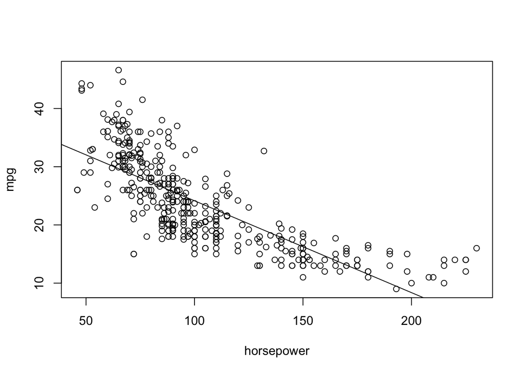

```r
plot(horsepower, mpg)
abline(lm.res)
```

Предположим, что между horsepower и mpg зависимость нелинейная

3. Use the plot() function to produce diagnostic plots of the least squares regression fit:

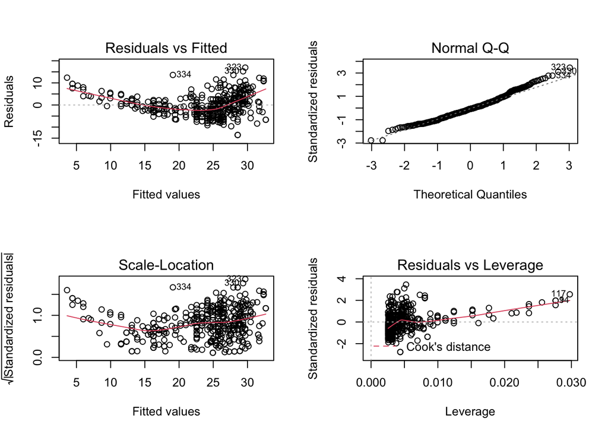

```r
par(mfrow = c(2, 2))
plot(lm.res)
```

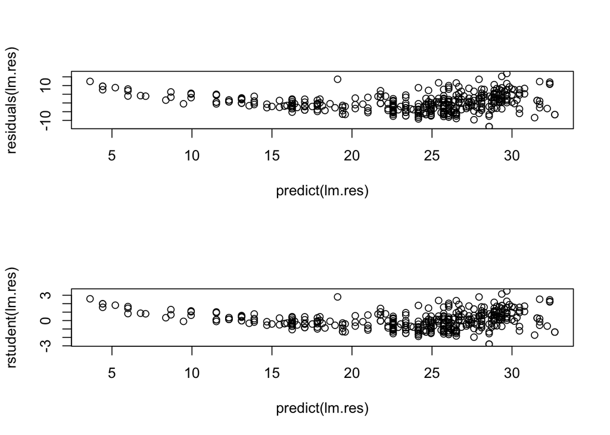

```r
par(mfrow = c(2, 1))
plot(predict(lm.res), residuals(lm.res))
plot(predict(lm.res), rstudent(lm.res))
```

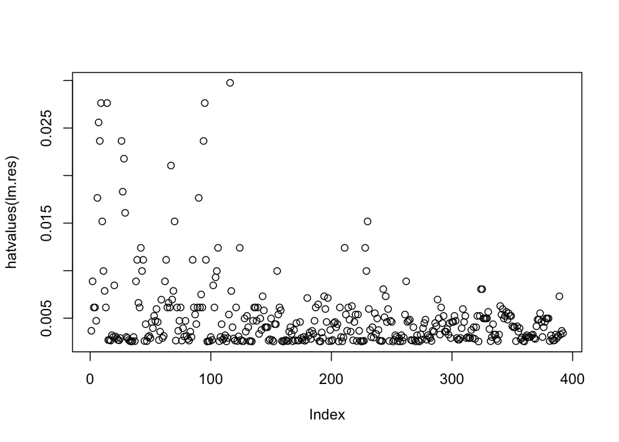

```r
par(mfrow = c(1, 1))
plot(hatvalues(lm.res))
```

Видим подтвержение предположения о нелинейности зависимости, а также outliers (однако так как модель неверна– зависимость нелинейная, то удаление таких outliers скорее будет подгонкой под модель)